# Lab 4: Mixed models and model selection

**Name:** Lauren Bolte

**Date:** 11/21/2025

# Introduction

The goal of this lab is to familiarize you with **building and comparing mixed models in R**.

You’ll be:

- Understanding when data violate the **independence assumption**.
- Fitting models with **random intercepts**.
- Fitting models with **random slopes**.
- Comparing models using **likelihood ratio tests**.
- Interpreting **fixed and random effects**.

We’ll be working with the **resume** dataset, the result of a field experiment in which researchers manipulated perceived characteristics of a job applicant (e.g., gender and race), controlling for other things (like their years of experience), and measured whether those maniuplated characteristics impacted the likelihood of an employer calling them back. In this lab, we’ll replicate some of those findings and also used mixed effects models to control for sources of non-independence.

## Load datasets

To get started, let’s load the dataset.

```r
library(tidyverse)
library(lme4)
### Resume dataset
df_resume <- read_csv("https://raw.githubusercontent.com/seantrott/ucsd_css211_datasets/main/main/logistic/resume.csv")
nrow(df_resume)
```

```
[1] 4870
```

# Part 1: The naive approach (ignoring non-independence)

Let’s start by analyzing these data the “wrong” way—treating all observations as independent. This will help us see why we need mixed models.

## Exercise 1: Basic exploration

Before building any models, let’s explore the data:

- How many unique job postings (`job_ad_id`) are in the dataset?

```r
length(unique(df_resume$job_ad_id))
```

```
[1] 1323
```

- How many resumes were sent per job on average? (Hint: group by `job_ad_id` and count)

```r
library(dplyr)
resume_counts <- df_resume %>%
  count(job_ad_id)
mean(resume_counts$n)
```

```
[1] 3.681028
```

- Create a visualization showing the distribution of the number of resumes per job.

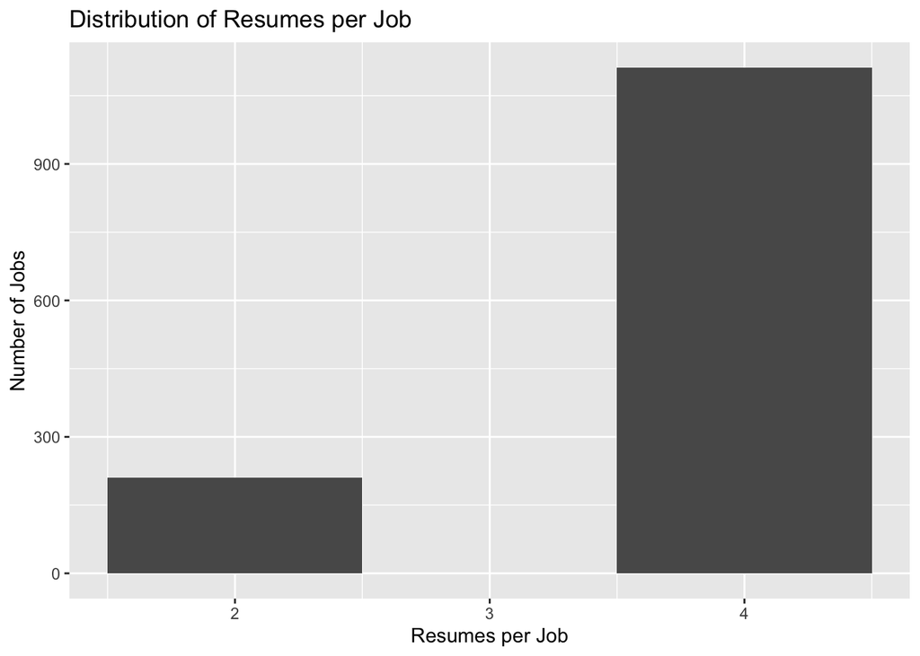

```r
library(ggplot2)


ggplot(resume_counts, aes(n)) +
  geom_histogram(binwidth = 1) +
  labs(
    title = "Distribution of Resumes per Job",
    x = "Resumes per Job",
    y = "Number of Jobs"
  )
```

- Calculate the overall callback rate.

```r
mean(df_resume$received_callback)
```

```
[1] 0.08049281
```

## Exercise 2: A naive model of race effects

Ignoring the nested structure, build a simple logistic regression predicting `received_callback` from `race`.

```r
race_callback_glm <- glm(
  received_callback ~ race,
  data = df_resume,
  family = binomial(link = "logit")
)

summary(race_callback_glm)
```

```
Call:
glm(formula = received_callback ~ race, family = binomial(link = "logit"),
    data = df_resume)

Coefficients:
            Estimate Std. Error z value Pr(>|z|)
(Intercept) -2.67481    0.08251 -32.417  < 2e-16 ***
racewhite    0.43818    0.10732   4.083 4.45e-05 ***
---
Signif. codes:  0 '***' 0.001 '**' 0.01 '*' 0.05 '.' 0.1 ' ' 1

(Dispersion parameter for binomial family taken to be 1)

    Null deviance: 2726.9  on 4869  degrees of freedom
Residual deviance: 2709.9  on 4868  degrees of freedom
AIC: 2713.9

Number of Fisher Scoring iterations: 5
```

There are a few sources of non-independence: `job_ad_id`, `job_city`, and `job_industry`.

- Calculate the `callback` rate for different ids, cities, and industries.

```r
callback_city <- df_resume %>%
  group_by(job_city) %>%
  summarise(callback_rate = mean(received_callback))
callback_city
```

```
# A tibble: 2 × 2
  job_city callback_rate
  <chr>            <dbl>
1 Boston          0.0970
2 Chicago         0.0673
```

```r
callback_adid <- df_resume %>%
  group_by(job_ad_id) %>%
  summarise(callback_rate = mean(received_callback))
callback_adid
```

```
# A tibble: 1,323 × 2
   job_ad_id callback_rate
       <dbl>         <dbl>
 1         1          0
 2         2          0
 3         3          0
 4         4          0
 5         5          0.25
 6         6          0
 7         7          0
 8         8          0
 9         9          0
10        10          0
# ℹ 1,313 more rows
```

```r
callback_industry <- df_resume %>%
  group_by(job_industry) %>%
  summarise(callback_rate = mean(received_callback))
callback_industry
```

```
# A tibble: 6 × 2
  job_industry                  callback_rate
  <chr>                                 <dbl>
1 business_and_personal_service        0.0836
2 finance_insurance_real_estate        0.0725
3 manufacturing                        0.0545
4 other_service                        0.0892
5 transportation_communication         0.135
6 wholesale_and_retail_trade           0.0691
```

- Visualize this to determine whether this varies across these sources of non-independence.

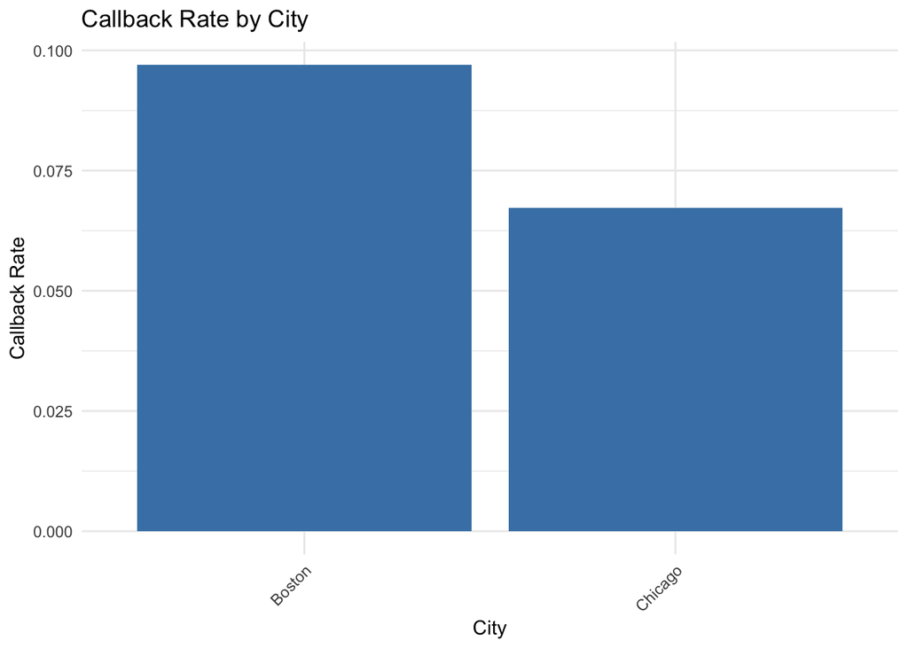

```r
ggplot(callback_city, aes(x = job_city, y = callback_rate)) +
  geom_col(fill = "steelblue") +
  labs(
    title = "Callback Rate by City",
    x = "City",
    y = "Callback Rate"
  ) +
  theme_minimal() +
  theme(axis.text.x = element_text(angle = 45, hjust = 1))
```

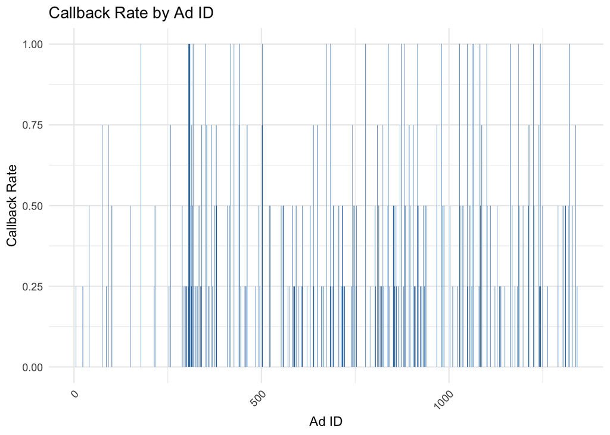

```r
ggplot(callback_adid, aes(x = job_ad_id, y = callback_rate)) +
  geom_col(fill = "steelblue") +
  labs(
    title = "Callback Rate by Ad ID",
    x = "Ad ID",
    y = "Callback Rate"
  ) +
  theme_minimal() +
  theme(axis.text.x = element_text(angle = 45, hjust = 1))
```

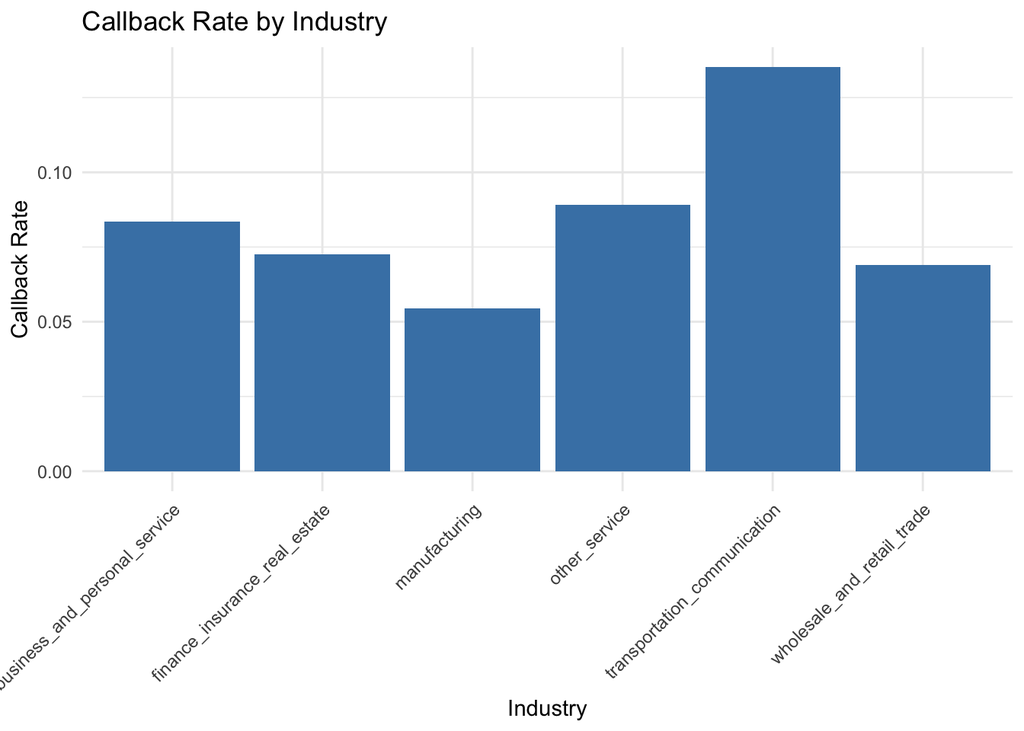

```r
ggplot(callback_industry, aes(x = job_industry, y = callback_rate)) +
  geom_col(fill = "steelblue") +
  labs(
    title = "Callback Rate by Industry",
    x = "Industry",
    y = "Callback Rate"
  ) +
  theme_minimal() +
  theme(axis.text.x = element_text(angle = 45, hjust = 1))
```

# Part 2: Random intercepts models

Now let’s properly account for the nested structure using mixed effects models.

## Exercise 4: Your first mixed model

Build a mixed effects model with a **random intercept** for each `job_ad_id`, `job_city`, and `job_industry`:

```r
library(lme4)

model_ri <- glmer(
  received_callback ~ race +
    (1 | job_ad_id) +
    (1 | job_city) +
    (1 | job_industry),
  data = df_resume,
  family = binomial(link = "logit")
)
```

```
boundary (singular) fit: see help('isSingular')
```

```r
summary(model_ri)
```

```
Generalized linear mixed model fit by maximum likelihood (Laplace
  Approximation) [glmerMod]
 Family: binomial  ( logit )
Formula: received_callback ~ race + (1 | job_ad_id) + (1 | job_city) +
    (1 | job_industry)
   Data: df_resume

      AIC       BIC    logLik -2*log(L)  df.resid
   1984.8    2017.2    -987.4    1974.8      4865

Scaled residuals:
     Min       1Q   Median       3Q      Max
-2.12770 -0.02108 -0.02108 -0.01216  2.58660

Random effects:
 Groups       Name        Variance Std.Dev.
 job_ad_id    (Intercept) 57.21    7.564
 job_industry (Intercept)  0.00    0.000
 job_city     (Intercept)  0.00    0.000
Number of obs: 4870, groups:  job_ad_id, 1323; job_industry, 6; job_city, 2

Fixed effects:
            Estimate Std. Error z value Pr(>|z|)
(Intercept)  -8.7517     0.3788 -23.105  < 2e-16 ***
racewhite     1.1010     0.1758   6.264 3.76e-10 ***
---
Signif. codes:  0 '***' 0.001 '**' 0.01 '*' 0.05 '.' 0.1 ' ' 1

Correlation of Fixed Effects:
          (Intr)
racewhite -0.457
optimizer (Nelder_Mead) convergence code: 0 (OK)
boundary (singular) fit: see help('isSingular')
```

- Compare the coefficient for `race` to the naive model. How has it changed?
  - race coefficient has more than doubled in size from the naive model
- Is the effect still significant?
  - yes, both fixed effects intercept and race coefficient are statistically significant

## Exercise 5: Extracting random intercepts

Extract and visualize the random intercepts for `job_ad_id`.

```r
random_int <- ranef(model_ri)$job_ad_id
```

- Create a histogram of the random intercept deviations.

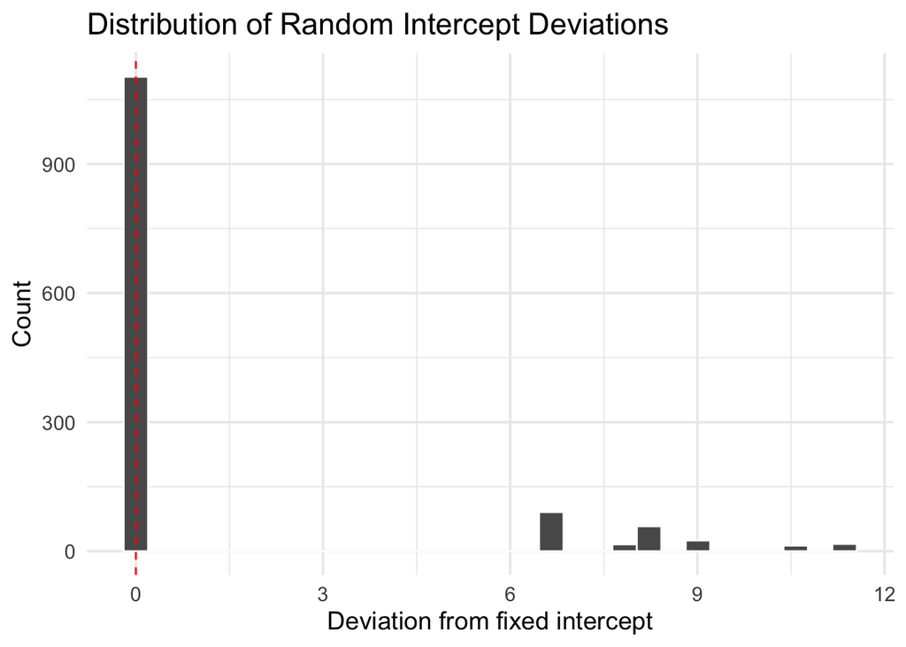

```r
intercept_df <- ranef(model_ri)$job_ad_id %>%
  rownames_to_column("job_ad_id") %>%
  rename(deviation = `(Intercept)`)

ggplot(intercept_df, aes(x = deviation)) +
  geom_histogram(bins = 30, color = "white") +
  geom_vline(xintercept = 0, linetype = "dashed", color = "red") +
  labs(
    title = "Distribution of Random Intercept Deviations",
    x = "Deviation from fixed intercept",
    y = "Count"
  ) +
  theme_minimal(base_size = 14)
```

- What is the range of these deviations?

```r
range(intercept_df$deviation)
```

```
[1] -0.06775804 11.29141267
```

- **Interpretation**: What does a positive vs. negative deviation mean for a particular job?
- A job with a negative deviation from the fixed intercept has a baseline intercept (callback rate) that is less than the overall baseline callback rate. A job with a positive deviation has a higher-than-average baseline callback rate after controlling for race.

# Part 3: Adding more complexity

## Exercise 7: Adding fixed effects

Build a model that includes additional predictors such as `years_experience` and `computer_skills`.

```r
model_add_pred <- glmer(
  received_callback ~ race + years_experience + computer_skills +
    (1 | job_ad_id) +
    (1 | job_city) +
    (1 | job_industry),
  data = df_resume,
  family = binomial(link = "logit")
)
```

```
boundary (singular) fit: see help('isSingular')
```

```r
summary(model_add_pred)
```

```
Generalized linear mixed model fit by maximum likelihood (Laplace
  Approximation) [glmerMod]
 Family: binomial  ( logit )
Formula: received_callback ~ race + years_experience + computer_skills +
    (1 | job_ad_id) + (1 | job_city) + (1 | job_industry)
   Data: df_resume

      AIC       BIC    logLik -2*log(L)  df.resid
   1979.3    2024.7    -982.6    1965.3      4863

Scaled residuals:
    Min      1Q  Median      3Q     Max
-2.2198 -0.0205 -0.0178 -0.0114  3.4930

Random effects:
 Groups       Name        Variance Std.Dev.
 job_ad_id    (Intercept) 57.15    7.56
 job_industry (Intercept)  0.00    0.00
 job_city     (Intercept)  0.00    0.00
Number of obs: 4870, groups:  job_ad_id, 1323; job_industry, 6; job_city, 2

Fixed effects:
                 Estimate Std. Error z value Pr(>|z|)
(Intercept)      -9.27665    0.48981 -18.939  < 2e-16 ***
racewhite         1.11337    0.17714   6.285 3.27e-10 ***
years_experience  0.05782    0.01856   3.115  0.00184 **
computer_skills   0.04635    0.25493   0.182  0.85574
---
Signif. codes:  0 '***' 0.001 '**' 0.01 '*' 0.05 '.' 0.1 ' ' 1

Correlation of Fixed Effects:
            (Intr) racwht yrs_xp
racewhite   -0.406
years_xprnc -0.431  0.048
cmptr_sklls -0.505  0.071  0.120
optimizer (Nelder_Mead) convergence code: 0 (OK)
boundary (singular) fit: see help('isSingular')
```

## Exercise 8: Model comparison

Compare the model constructed in (7) to a model omitting only the fixed effect of `race` using a likelihood-ratio test. Is the full model an improvement?

```r
model_remove_race <- glmer(
  received_callback ~ years_experience + computer_skills +
    (1 | job_ad_id) +
    (1 | job_city) +
    (1 | job_industry),
  data = df_resume,
  family = binomial(link = "logit")
)
```

```
boundary (singular) fit: see help('isSingular')
```

```r
anova(model_add_pred, model_remove_race)
```

```
Data: df_resume
Models:
model_remove_race: received_callback ~ years_experience + computer_skills + (1 | job_ad_id) + (1 | job_city) + (1 | job_industry)
model_add_pred: received_callback ~ race + years_experience + computer_skills + (1 | job_ad_id) + (1 | job_city) + (1 | job_industry)
                  npar    AIC    BIC   logLik -2*log(L)  Chisq Df Pr(>Chisq)
model_remove_race    6 2019.6 2058.6 -1003.81    2007.6
model_add_pred       7 1979.3 2024.7  -982.64    1965.3 42.346  1  7.646e-11

model_remove_race
model_add_pred    ***
---
Signif. codes:  0 '***' 0.001 '**' 0.01 '*' 0.05 '.' 0.1 ' ' 1
```

- The full model has a better fit because the log likelihood is higher and the AIC is lower.

## Submission Instructions

1. Make sure all your code chunks run without errors
2. Save this file with your name in the filename (e.g., “Lab1_YourLastName.qmd”)
3. Render the document to HTML
4. Submit both the .qmd file and the rendered HTML file to Canvas